# Clustering: sports analytics

Statistical Learning, Bachelor in Data Science and Engineering

UC3M, 2022

# Motivation

**Sports analytics:** collection of relevant, historical, statistics that can provide a competitive advantage to a team or individual.

In this case study, we will analyze data from NBA

In basketball, there are typically 5 positions for players: point guard, shooting guard, small forward, power forward, and center

Hence, NBA players should fall into these 5 categories

Some questions to be answered:

- But is this really the case? NBA players may have skills that exceed their predefined positions.
- Can we use data performance to discover new groups (alternative position names) based on player skills (how they play)? What’s the meaning of these groups?

Based on data of all-time leaders from here: http://stats.nba.com/alltime-leaders/

```r
# delete everything
rm(list=ls())

library(tidyverse)
library(GGally) # ggplot2-based visualization of correlations
library(factoextra) # ggplot2-based visualization of pca
library(cluster)
```

## Load and prepare data

The dataset contains skill performance of the most important NBA players in the history

See the glossary here: http://stats.nba.com/alltime-leaders/

Performance is per game

```r
historical_players.df = read.csv(file = "nba.csv", header=T, sep=";")

glimpse(historical_players.df)
```

```
## Rows: 1,214
## Columns: 26
## $ player_id   <int> 893, 76375, 76127, 201142, 2544, 78497, 947, 77847, 76804,…
## $ player_name <chr> "Michael Jordan", "Wilt Chamberlain", "Elgin Baylor", "Kev…
## $ gp          <int> 1072, 1045, 846, 703, 1061, 932, 914, 792, 791, 1040, 1476…
## $ min         <dbl> 38.25653, 45.79809, 40.02719, 37.37980, 38.90009, 39.23927…
## $ fgm         <dbl> 11.37313, 12.13493, 10.27541, 9.19346, 9.82375, 9.67382, 9…
## $ fga         <dbl> 22.88899, 22.48517, 23.84279, 18.85349, 19.60697, 20.42060…
## $ fg_pct      <dbl> 0.497, 0.540, 0.431, 0.488, 0.501, 0.474, 0.425, 0.436, 0.…
## $ fg3m        <dbl> 0.54198, NA, NA, 1.79232, 1.38266, NA, 1.15864, NA, 0.0973…
## $ fg3a        <dbl> 1.65858, NA, NA, 4.72404, 4.04807, NA, 3.70131, NA, 0.3274…
## $ fg3_pct     <dbl> 0.327, NA, NA, 0.379, 0.342, NA, 0.313, NA, 0.297, NA, 0.2…
## $ ftm         <dbl> 6.83489, 5.79617, 6.81206, 7.01991, 6.10179, 7.68240, 6.97…
## $ fta         <dbl> 8.18284, 11.35120, 8.73641, 7.96017, 8.24882, 9.44313, 8.9…
## $ ft_pct      <dbl> 0.835, 0.511, 0.780, 0.882, 0.740, 0.814, 0.780, 0.761, 0.…
## $ oreb        <dbl> 1.55597, NA, NA, 0.78663, 1.21489, 0.96774, 0.81510, NA, 1…
## $ dreb        <dbl> 4.66791, NA, NA, 6.36984, 6.04807, 2.77419, 2.89825, NA, 3…
## $ reb         <dbl> 6.22388, 22.89378, 13.54965, 7.15647, 7.26296, 5.76824, 3.…
## $ ast         <dbl> 5.25466, 4.44306, 4.31442, 3.78805, 7.03205, 6.69313, 6.15…
## $ stl         <dbl> 2.34515, NA, NA, 1.19488, 1.64844, 2.61290, 2.16958, NA, 1…
## $ blk         <dbl> 0.83302, NA, NA, 1.04979, 0.77003, 0.74194, 0.17943, NA, 0…
## $ tov         <dbl> 2.72761, NA, NA, 3.15932, 3.41093, NA, 3.56893, NA, 3.0141…
## $ pf          <dbl> 2.59608, 1.98565, 3.06856, 1.89189, 1.86334, 2.61266, 1.94…
## $ pts         <dbl> 30.12313, 30.06603, 27.36288, 27.19915, 27.13195, 27.03004…
## $ ast_tov     <dbl> 1.92647, NA, NA, 1.19901, 2.06162, NA, 1.72410, NA, 0.9246…
## $ stl_tov     <dbl> 0.85978, NA, NA, 0.37821, 0.48328, NA, 0.60791, NA, 0.3912…
## $ efg_pct     <dbl> 0.50872, 0.53969, 0.43097, 0.53516, 0.53629, 0.47373, 0.45…
## $ ts_pct      <dbl> 0.56859, 0.54706, 0.49415, 0.60832, 0.58382, 0.54994, 0.51…
```

These are the 1200 best players in the NBA history

## Missing values

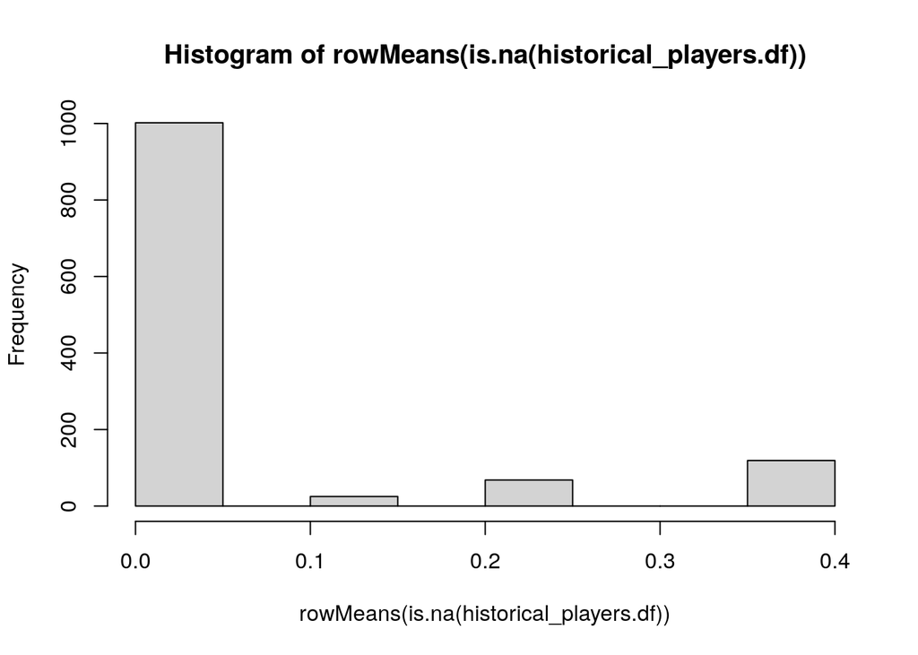

```r
hist(rowMeans(is.na(historical_players.df)))
```

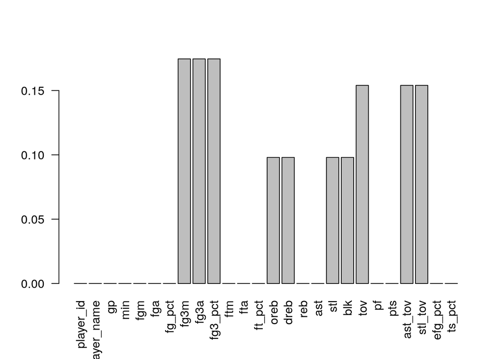

```r
barplot(colMeans(is.na(historical_players.df)), las=2)
```

```r
# skip players with NA information in any variable
historical_players.df <-
  historical_players.df[rowSums(is.na(historical_players.df)) == 0,]
dim(historical_players.df)
```

```
## [1] 1002   26
```

Conclusions? What can we do?

Create the data frame

```r
nba <- historical_players.df[,3:ncol(historical_players.df)]
nba <- as.data.frame(sapply(nba, as.numeric ))
names = historical_players.df[,2]

dim(nba)
```

```
## [1] 1002   24
```

```r
summary(nba)
```

```
##        gp              min              fgm               fga
##  Min.   : 400.0   Min.   : 8.947   Min.   : 0.6232   Min.   : 1.531
##  1st Qu.: 532.5   1st Qu.:20.489   1st Qu.: 2.7673   1st Qu.: 5.963
##  Median : 682.5   Median :25.101   Median : 3.7753   Median : 8.220
##  Mean   : 718.5   Mean   :25.163   Mean   : 4.0994   Mean   : 8.819
##  3rd Qu.: 861.0   3rd Qu.:29.802   3rd Qu.: 5.2043   3rd Qu.:11.172
##  Max.   :1611.0   Max.   :41.120   Max.   :11.3731   Max.   :22.889
##      fg_pct            fg3m               fg3a            fg3_pct
##  Min.   :0.3730   Min.   :0.000000   Min.   :0.00000   Min.   :0.0000
##  1st Qu.:0.4370   1st Qu.:0.006258   1st Qu.:0.04473   1st Qu.:0.1520
##  Median :0.4610   Median :0.137780   Median :0.47784   Median :0.2945
##  Mean   :0.4645   Mean   :0.430171   Mean   :1.22112   Mean   :0.2492
##  3rd Qu.:0.4900   3rd Qu.:0.793380   3rd Qu.:2.20637   3rd Qu.:0.3510
##  Max.   :0.6770   Max.   :3.339720   Max.   :7.62892   Max.   :1.0000
##       ftm              fta             ft_pct            oreb
##  Min.   :0.2141   Min.   :0.2441   Min.   :0.4140   Min.   :0.1456
##  1st Qu.:1.1963   1st Qu.:1.6486   1st Qu.:0.7060   1st Qu.:0.6621
##  Median :1.7713   Median :2.4028   Median :0.7630   Median :1.1722
##  Mean   :2.0709   Mean   :2.7368   Mean   :0.7492   Mean   :1.3260
##  3rd Qu.:2.6476   3rd Qu.:3.5213   3rd Qu.:0.8060   3rd Qu.:1.8559
##  Max.   :7.1539   Max.   :9.3223   Max.   :0.9050   Max.   :5.0647
##       dreb             reb              ast               stl
##  Min.   :0.7673   Min.   : 1.007   Min.   : 0.1975   Min.   :0.1225
##  1st Qu.:2.0071   1st Qu.: 2.781   1st Qu.: 1.1235   1st Qu.:0.5405
##  Median :2.8147   Median : 4.031   Median : 1.9202   Median :0.7761
##  Mean   :3.1508   Mean   : 4.492   Mean   : 2.4371   Mean   :0.8537
##  3rd Qu.:3.9814   3rd Qu.: 5.833   3rd Qu.: 3.3430   3rd Qu.:1.0794
##  Max.   :9.7748   Max.   :13.993   Max.   :11.1932   Max.   :2.7112
##       blk               tov               pf              pts
##  Min.   :0.00996   Min.   :0.1734   Min.   :0.7944   Min.   : 1.729
##  1st Qu.:0.18856   1st Qu.:1.0697   1st Qu.:1.9307   1st Qu.: 7.144
##  Median :0.34270   Median :1.5038   Median :2.2904   Median : 9.769
##  Mean   :0.52666   Mean   :1.5942   Mean   :2.3360   Mean   :10.700
##  3rd Qu.:0.69759   3rd Qu.:2.0263   3rd Qu.:2.7452   3rd Qu.:13.634
##  Max.   :3.50171   Max.   :3.9222   Max.   :3.8665   Max.   :30.123
##     ast_tov          stl_tov          efg_pct           ts_pct
##  Min.   :0.2445   Min.   :0.1320   Min.   :0.4069   Min.   :0.4294
##  1st Qu.:0.9114   1st Qu.:0.4061   1st Qu.:0.4675   1st Qu.:0.5105
##  Median :1.3036   Median :0.5208   Median :0.4866   Median :0.5295
##  Mean   :1.4672   Mean   :0.5600   Mean   :0.4885   Mean   :0.5307
##  3rd Qu.:1.9264   3rd Qu.:0.6748   3rd Qu.:0.5066   3rd Qu.:0.5504
##  Max.   :4.6936   Max.   :1.9345   Max.   :0.6771   Max.   :0.6433
```

Around 200 players were deleted.

## Some feature engineering

The following is optional, but makes sense for a coacher

I.e. we will use variables depending on player’s skills, not coacher’s decisions

```r
# skip variable gp (games played) which is decided by the coach
gp = nba$gp
nba$gp = NULL

# skip the min variable (minutes played per game) which is decided by the coach
min = nba$min
nba$min = NULL
```

Take care: there are some redundant variables, for instance

- fgm, fga, and fg_pct
- fg3m, fg3a, and fg3_pct
- ftm, fta, and ft_pct
- oreb, dreb, and reb

Should we skip some of previous variables?

```r
nba = nba[,-c(3,6,9,12,19,20,21,22)]
dim(nba)
```

```
## [1] 1002   14
```

## Descriptive Analysis

Our input has dimension $p=14$, that implies $2^p$ different relations between the variables.

Remember PCA interpretation and output

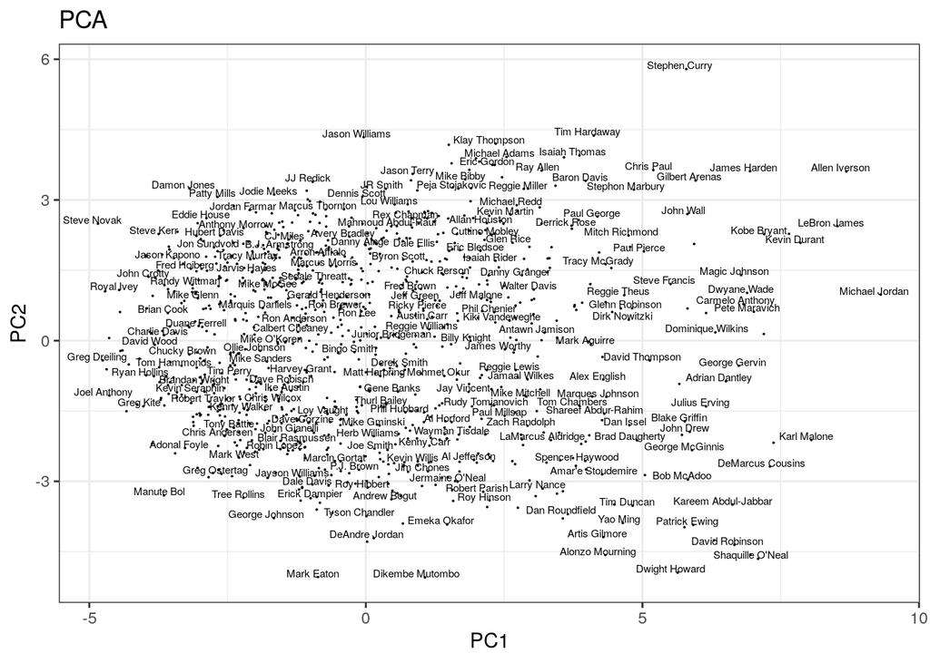

```r
pca = prcomp(nba, scale=T)

# Plot the first two scores
data.frame(z1=-pca$x[,1],z2=pca$x[,2]) %>%
  ggplot(aes(z1,z2,label=names)) + geom_point(size=0) +
  labs(title="PCA", x="PC1", y="PC2") +
  theme_bw() +theme(legend.position="bottom") + geom_text(size=2, hjust=0.6, vjust=0, check_overlap = TRUE)
```

We will use this representation when plotting our clusters. That is, the position of the players will be the same, but we will add colors for different clusters. This will be called the **clusplot**.

# Clustering

## kmeans

Let’s start creating 5 clusters (the typical number of different positions) using kmeans

```r
X = scale(nba)

fit = kmeans(X, centers=5, nstart=100)
groups = fit$cluster
groups
```

```
##    [1] 2 2 2 2 2 2 2 2 2 2 2 2 2 2 2 2 5 2 2 5 2 2 2 2 2 2 2 2 2 2 5 2 2 2 2 2 5
##   [38] 2 2 2 2 2 2 2 2 5 5 5 2 5 5 2 2 5 2 5 5 2 5 5 2 5 2 2 2 5 2 5 5 5 5 5 2 2
##   [75] 2 2 5 2 5 5 5 5 5 5 2 2 2 5 5 5 2 5 2 2 5 2 5 2 5 2 2 2 5 2 5 2 4 5 5 5 2
##  [112] 2 5 5 2 5 2 5 5 2 5 2 5 2 5 2 5 2 5 2 5 5 2 4 5 5 5 4 5 5 5 2 5 5 5 5 4 5
##  [149] 5 5 4 2 5 2 2 5 5 5 5 5 5 4 2 5 5 2 5 2 5 5 4 5 5 4 5 2 4 5 5 5 5 5 4 5 5
##  [186] 2 5 5 4 5 5 2 5 5 5 5 5 2 5 2 5 5 4 4 4 5 5 4 4 5 5 5 4 5 5 5 4 5 5 5 5 4
##  [223] 5 4 5 5 5 5 5 5 2 4 5 4 4 5 4 4 5 5 5 5 4 5 5 5 5 5 4 4 5 4 5 5 4 4 5 4 4
##  [260] 5 5 5 5 4 5 5 5 4 4 5 5 4 4 5 4 1 5 4 5 5 5 4 5 4 5 5 4 4 4 1 4 4 4 5 4 5
##  [297] 5 5 4 5 4 5 5 4 5 4 4 5 5 5 5 4 5 5 5 4 4 4 4 5 5 5 5 5 4 4 1 4 4 5 5 4 4
##  [334] 4 1 4 4 5 4 4 1 5 4 4 1 1 4 4 1 1 4 4 5 5 4 4 4 1 1 4 4 4 5 1 4 1 5 5 5 5
##  [371] 4 1 4 4 4 4 1 1 4 1 4 4 4 5 5 5 4 5 1 4 1 5 1 4 4 4 1 5 1 4 4 5 4 1 5 5 1
##  [408] 5 5 1 5 1 4 4 1 5 1 4 5 1 1 4 4 4 4 4 1 5 4 4 4 5 1 1 4 4 4 4 1 1 5 4 5 1
##  [445] 1 1 4 1 5 4 1 1 1 4 5 4 1 1 4 1 4 4 4 1 1 4 4 4 4 1 4 5 4 4 4 1 4 4 1 5 1
##  [482] 4 4 4 4 4 1 3 1 1 1 1 1 1 1 1 4 1 1 1 1 1 3 1 1 1 4 4 4 1 1 5 1 4 3 1 4 1
##  [519] 1 1 1 4 4 1 4 1 1 4 1 4 3 5 4 4 4 4 1 4 1 1 1 1 1 4 3 1 1 1 1 4 1 3 4 3 4
##  [556] 1 1 1 4 4 1 4 1 1 1 1 4 1 1 4 1 1 1 1 1 1 4 4 1 4 4 1 1 1 4 3 1 1 1 4 3 1
##  [593] 1 3 4 3 3 4 3 1 1 1 1 1 1 1 4 1 1 1 1 3 3 5 1 1 1 1 4 1 4 3 3 1 1 1 3 1 1
##  [630] 1 1 4 1 1 1 4 1 1 1 3 4 1 1 3 1 1 3 3 1 4 4 1 1 4 3 4 1 1 1 3 3 1 1 3 4 4
##  [667] 3 3 4 1 1 1 4 3 1 3 1 4 1 1 1 1 1 3 3 3 3 3 1 1 3 4 1 1 3 4 1 1 3 1 4 3 1
##  [704] 1 1 3 1 1 1 1 1 3 3 1 3 1 1 1 3 3 1 4 1 1 4 1 3 4 3 4 1 1 4 3 3 3 1 4 1 3
##  [741] 1 1 3 4 1 3 1 1 1 4 4 1 3 3 1 1 3 3 3 1 3 3 3 1 1 3 1 1 3 3 1 1 1 3 3 1 1
##  [778] 1 1 1 3 3 3 3 1 3 3 3 3 1 3 3 3 3 4 1 3 1 3 1 4 1 3 1 3 1 1 3 3 1 1 1 1 1
##  [815] 3 3 1 3 1 3 1 3 1 3 1 1 1 3 1 1 3 1 3 3 1 3 3 3 4 1 3 3 3 3 3 1 3 3 3 3 3
##  [852] 1 4 3 3 1 1 3 1 3 1 3 3 3 3 3 3 4 1 3 3 3 3 3 1 3 1 1 3 1 3 1 3 1 3 3 3 3
##  [889] 3 3 3 3 3 3 3 3 3 3 1 1 3 3 1 3 3 1 3 1 1 3 3 1 3 3 3 3 3 3 3 1 3 3 3 3 1
##  [926] 3 3 4 1 1 3 3 3 1 3 3 3 3 1 3 3 1 3 3 1 3 3 1 3 1 3 3 1 3 3 3 3 3 3 3 3 3
##  [963] 3 3 3 3 3 1 3 3 3 3 3 3 3 3 1 3 1 3 3 3 3 3 3 1 1 3 3 3 3 3 3 3 3 3 3 3 3
## [1000] 3 3 3
```

The output is one category for each player. This is usually the case for all the (deterministic) clustering tools

Are the groups well balanced?

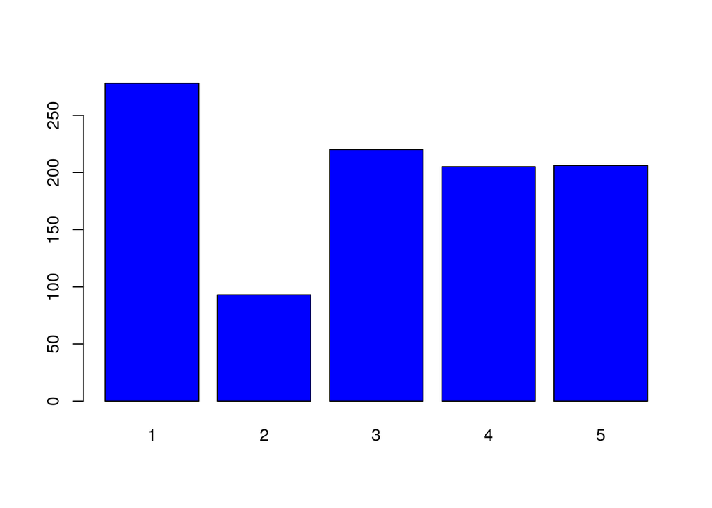

```r
barplot(table(groups), col="blue")
```

Insights?

## Interpretation

Let’s understand the meaning of the centers (artificial players representing each group)

```r
centers=fit$centers
centers
```

```
##          fgm         fga       fg3m       fg3a         ftm        fta
## 1 -0.5408269 -0.44447906  0.4682255  0.4611711 -0.59818319 -0.6710123
## 2  1.8784138  1.73629737 -0.2964663 -0.2682624  1.98126677  2.0461817
## 3 -0.9698070 -1.04295119 -0.7000063 -0.7264866 -0.76539380 -0.6948018
## 4  0.1431751  0.02855033 -0.6049455 -0.6160810  0.09779051  0.2061365
## 5  0.7750681  0.90138820  0.8515529  0.8877014  0.63289659  0.5186647
##         oreb       dreb         ast         stl        blk        tov
## 1 -0.8781773 -0.7647460  0.03807134 -0.04296428 -0.6252656 -0.5197854
## 2  1.1369092  1.4867162  0.44702775  0.63465432  0.9245510  1.5438121
## 3  0.2102893 -0.2276999 -0.86271930 -0.85614815  0.1807596 -0.9330711
## 4  1.0378050  0.9235593 -0.43232608 -0.23128498  0.7148681  0.1430987
## 5 -0.5854997 -0.3150530  1.09838679  0.91595742 -0.4780315  0.8585740
##            pf         pts
## 1 -0.82443066 -0.50551963
## 2  0.93418554  1.88247739
## 3 -0.05467881 -1.00377044
## 4  0.88547528  0.06391052
## 5 -0.13194480  0.84073737
```

Who are the players in the first group? And in the second one?

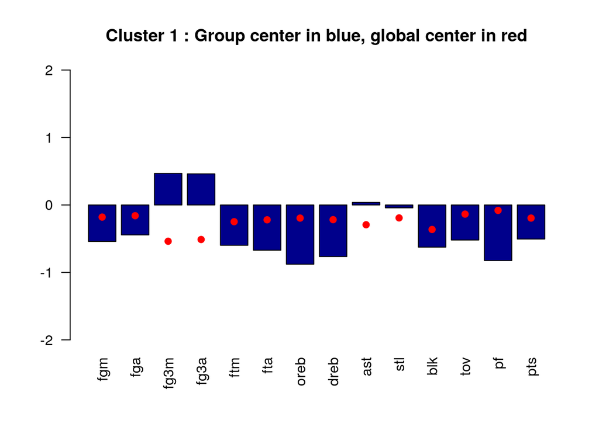

```r
i=1  # plotting the centers in cluster 1
bar1=barplot(centers[i,], las=2, col="darkblue", ylim=c(-2,2), main=paste("Cluster", i,": Group center in blue, global center in red"))
points(bar1,y=apply(X, 2, quantile, 0.50),col="red",pch=19)
```

The blue bars represent the center of a group, whereas the red points represent the center of all the NBA players

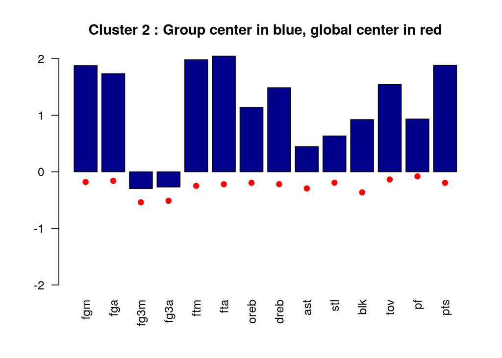

```r
i=2  # plotting the centers in cluster 2
bar2=barplot(centers[i,], las=2, col="darkblue", ylim=c(-2,2), main=paste("Cluster", i,": Group center in blue, global center in red"))
points(bar2,y=apply(X, 2, quantile, 0.50),col="red",pch=19)
```

## The clusplot

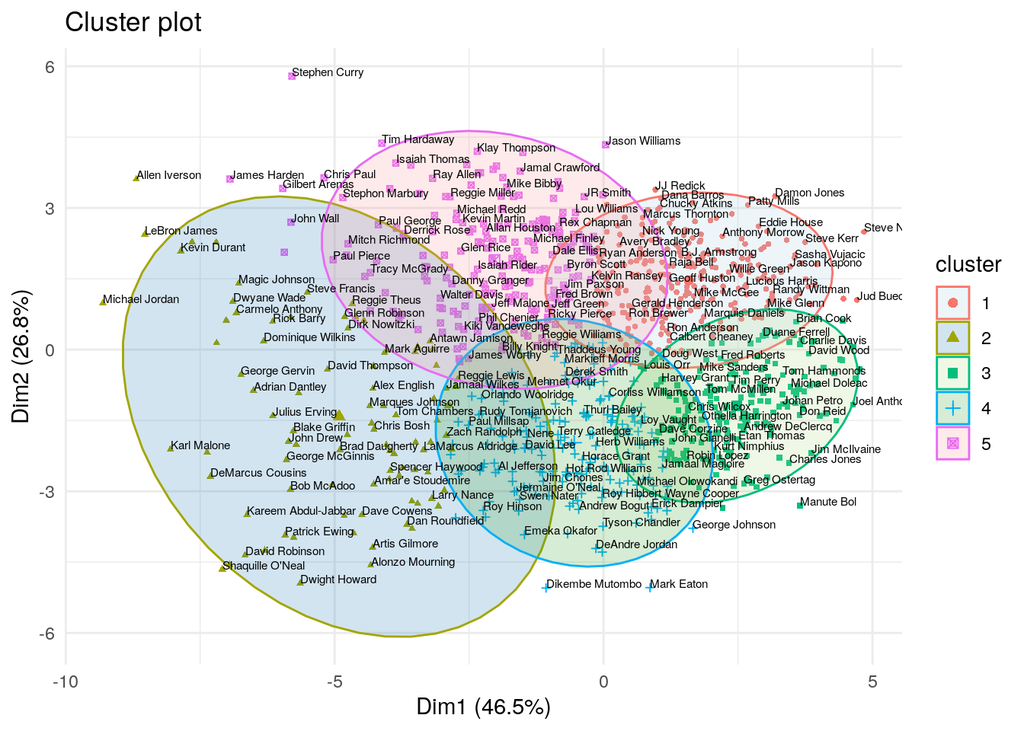

```r
fviz_cluster(fit, data = X, geom = c("point"),ellipse.type = 'norm', pointsize=1)+
  theme_minimal()+geom_text(label=names,hjust=0, vjust=0,size=2,check_overlap = T)+scale_fill_brewer(palette="Paired")
```

## The Silhouette plot

The silhouette value in [-1,1] measures the similarity (cohesion) of a data point to its cluster relative to other clusters (separation).

Silhouette plots rely on a distance metric and suggest that the data matches its own cluster well.

The larger the silhouette widths, the better.

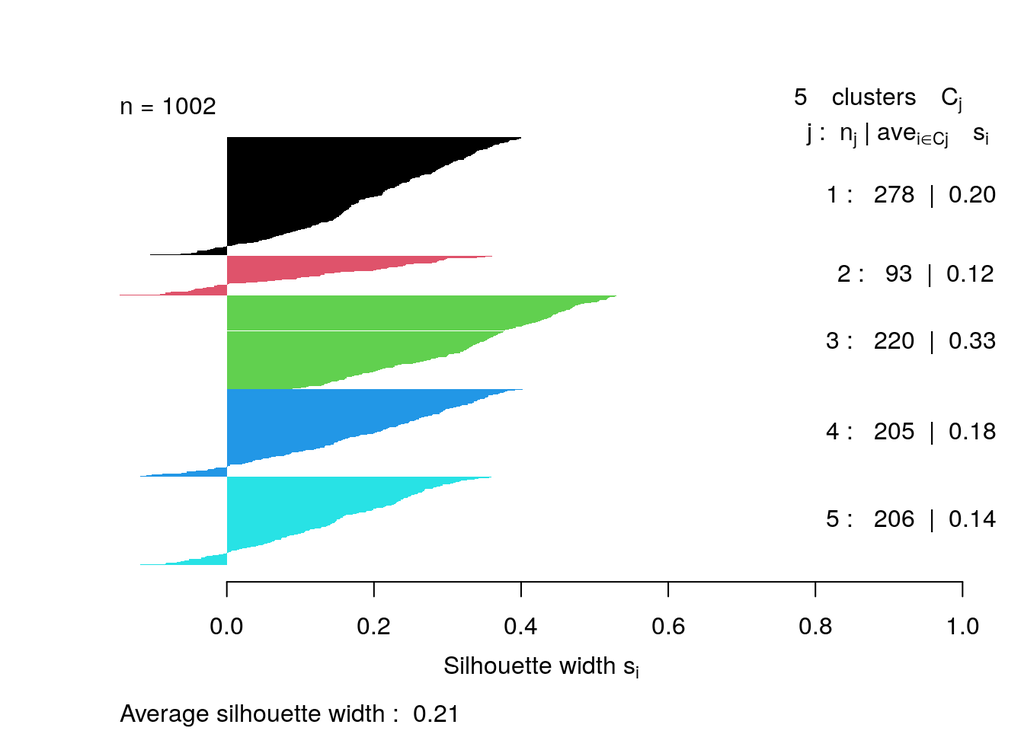

```r
d <- dist(X, method="euclidean")
sil = silhouette(groups, d)
plot(sil, col=1:5, main="", border=NA)
```

```r
summary(sil)
```

```
## Silhouette of 1002 units in 5 clusters from silhouette.default(x = groups, dist = d) :
##  Cluster sizes and average silhouette widths:
##       278        93       220       205       206
## 0.1965663 0.1220498 0.3318040 0.1813903 0.1440822
## Individual silhouette widths:
##    Min. 1st Qu.  Median    Mean 3rd Qu.    Max.
## -0.1453  0.1071  0.2125  0.2054  0.3124  0.5298
```